# **W05 多变量图表 Multivariate Plots**

## 5.2 绘制热力图

使用 Table 5.1-2 绘制热力图，见 Figure 5.2-1：

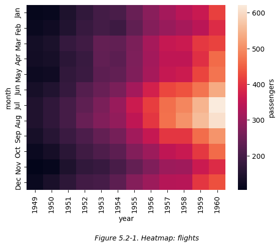

```python
# 用刚生成的透视表 (Table 5.1-2) 画热力图
sns.heatmap(data=flights_pivot, cbar_kws={'label':'passengers'})

    #【data】
    # .heatmap 直接使用矩阵形式的表格画图，而不是通过指定 x/y 参数为原 dataframe 中的特定列来画图。

    #【cbar_kws】
    # colorbar keyword arguments 彩色条关键字参数。此处设置了色彩条的标签。

plt.figtext(0.5,-0.1,"Figure 5.2-1. Heatmap: flights",ha="center",fontsize=10,style='italic')
plt.show()
```

还可以通过设置 `sns.heatmap()` 函数中的 其他参数（如：`cmap`，`annot`）来进一步修改热力图，如下图（Figure 5.2-2）：

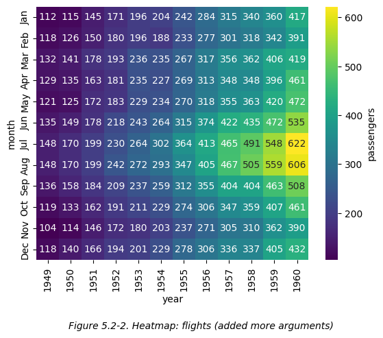

```python
# 设置热力图的其他参数
sns.heatmap(
    data=flights_pivot, cbar_kws={'label':'passengers'},
    cmap='viridis',  # 更改使用的 colormap（Matplotlib 中预制的 colormap）
    annot=True,   # annotation，给热力图格子添加注释，显示 data 使用的表格中的数据
    fmt = '.0f',  # format，和 annot 联用。'.nf'是用于更改浮点数格式的代码，
                # 意为 “保留到第n位小数”，此处 n=0，即为保留整数。
)

    #【cmap】
    # colormap。设置热力图使用的颜色图 (colormap)。
    # 可以使用 Seaborn 或 Matplotlib 中预制的 color palette 或 colormap 名称，
    # 如：'crest','flare', 'viridsis','pink' 等。


plt.figtext(0.5,-0.1,"Figure 5.2-2. Heatmap: flights (added more arguments)",
            ha="center",fontsize=10,style='italic')
plt.show()
```

同理，也可以使用 Table 5.1-4 绘制热力图，见下图 (Figure 5.2-3)：

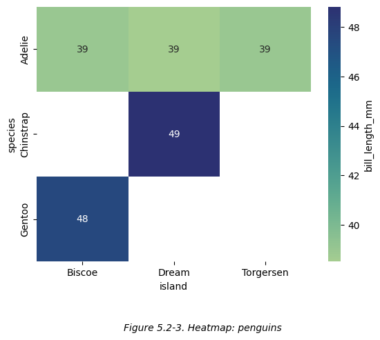

```python
sns.heatmap(data=df_pivot,cmap='crest',cbar_kws={'label':'bill_length_mm'},annot=True)

plt.figtext(0.5,-0.1,"Figure 5.2-3. Heatmap: penguins",ha="center",fontsize=10,style='italic')
plt.show()
```

# 6. 二维直方图 2-dimensional histogram

根据 Wilke (2019, pp. 222-225) 介绍，我们可以使用含有半透明点的散点图展示数据在两个变量控制下的分布情况，然而如果数据点过多、过密，就会导致散点图难以展示整体数据分布。如下图 (Figure 6-1) 点密度高的区域将显示为深色的均匀斑点，而在点密度低的区域中，各个点几乎不可见。

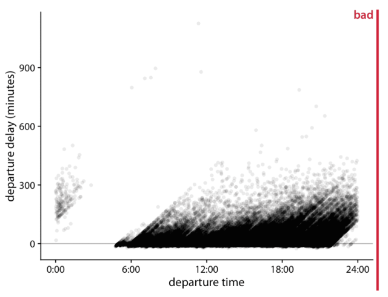

*Figure 6-1. 数据点过多、过密的散点图 (Wilke, 2019, p. 223)*

此时，我们可以改用 **二维直方图/2D直方图 (2-dimenl histogram)**，而不是绘制单个点（散点图）。二维直方图将整个 x - y 平面细分为小矩形，每个矩形是一个分箱 (bin)，并计算落入每个分箱的数据量，然后按照数据量的大小对矩形进行着色。如下图 (Figure 6-2)：

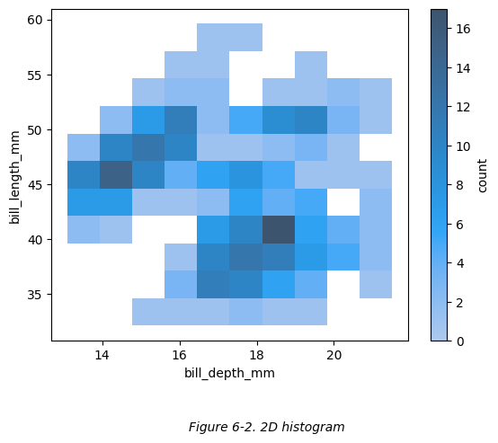

```python
# 绘制 2D 直方图
sns.histplot(
    data=df, x='bill_depth_mm', y='bill_length_mm',
    cbar=True,   #【cbar】colorbar。cbar 为 True 时，展示色彩条。
    cbar_kws={'label': 'count'},   # 给色彩条添加标签 'count'
)

plt.figtext(0.5,-0.1,"Figure 6-2. 2D histogram",ha="center",fontsize=10,style='italic')
plt.show()
```

**下表 (Table 6-1) 展示了热力图和二维直方图的区别：**

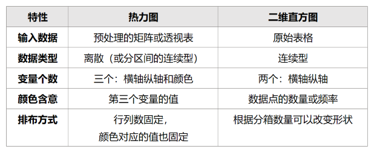

*Table 6-1. 热力图和二维直方图的区别*

# 7. 双变量图 Joint Plot

利用 Seaborn 的 `sns.jointplot()` 函数，我们可以画一个双变量图，同时展示包含两个变量的二元分布图，和这两个变量各自的一元分布图。

如下图 (Figure 7-1)，我们可以在展示二维直方图 (同 Figure 6-2) 的同时，展示两个变量各自的一维直方图。

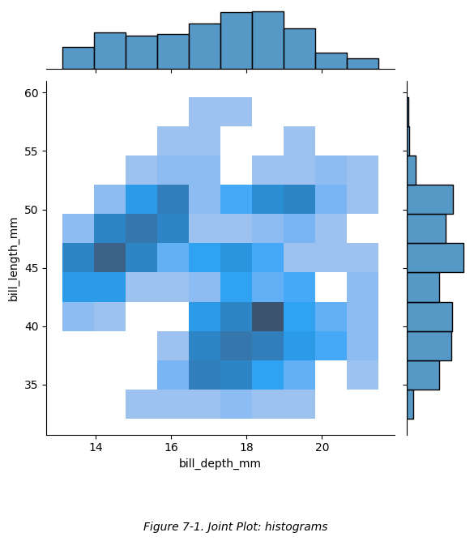

```python
# 双变量图：直方图
sns.jointplot(data=df, x='bill_depth_mm', y='bill_length_mm', kind='hist')

    #【kind】默认为 'scatter'，即，图中间的二元分布图（大图）默认为散点图形式（如 Figure 7-3）。此处设置为直方图了。

plt.figtext(0.5,-0.1,"Figure 7-1. Joint Plot: histograms",ha="center",fontsize=10,style='italic')
plt.show()
```

还可以通过控制参数 `kind='hex'` 来让中间的各自呈六边形，如下图 (Figure 7-2)：

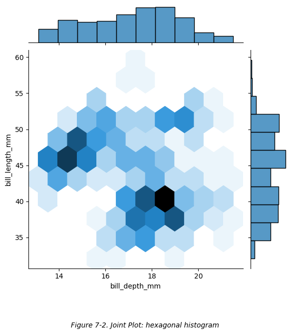

```python
# 双变量图：六边形图
sns.jointplot(data=df, x='bill_depth_mm', y='bill_length_mm', kind='hex')

    #【kind='hex'】hexagonal。让中间的二元分布图呈六边形。

plt.figtext(0.5,-0.1,"Figure 7-2. Joint Plot: hexagonal histogram",ha="center",fontsize=10,style='italic')
plt.show()
```

还可以展示其他形式的分布图，如下图 (Figure 7-3)：

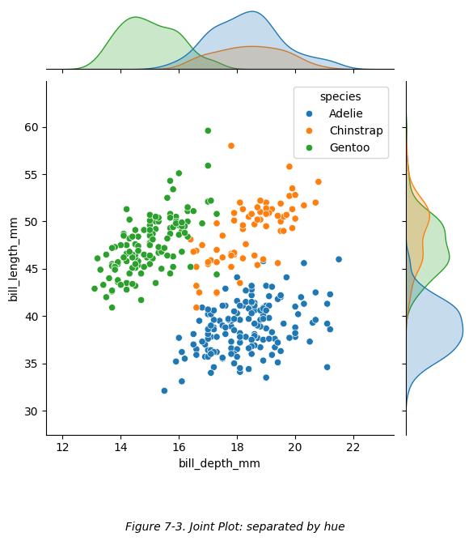

```python
# 双变量图：用颜色区分
sns.jointplot(data=df, x="bill_depth_mm", y="bill_length_mm",hue="species")

    #【hue】用颜色区分企鹅种类。
    #【⭕注】此处由于使用了 hue，外部的一元分布图自动变为密度图形式。

plt.figtext(0.5,-0.1,"Figure 7-3. Joint Plot: separated by hue",ha="center",fontsize=10,style='italic')
plt.show()
```

还可以通过设置参数 `kind='kde'` (abbr. 'kernal density estimation') 来生成自动光滑化的分布曲线，如下图 (Figure 7-4)。但是由于光滑化后的曲线并非真实数据，可能会误导读者，尤其是当数据点量非常少的时候。因此不建议在本课程中使用。

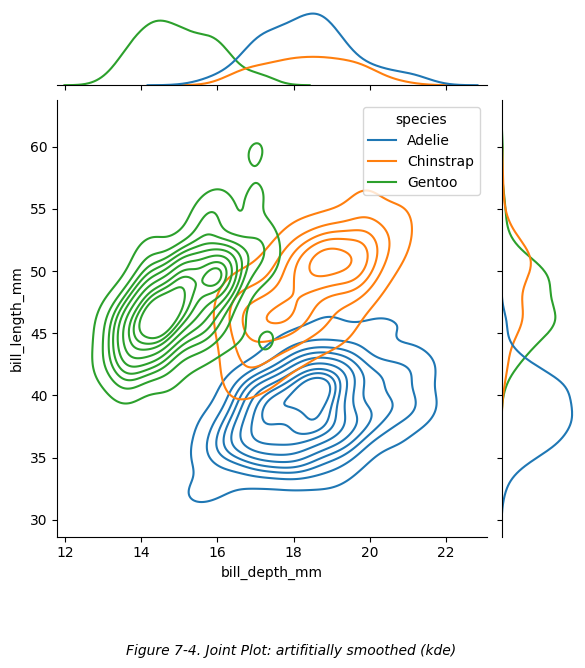

```python
# 双变量图：用颜色区分
sns.jointplot(data=df, x="bill_depth_mm", y="bill_length_mm",hue="species",kind='kde')

plt.figtext(0.5,-0.1,"Figure 7-4. Joint Plot: artifitially smoothed (kde)",
            ha="center",fontsize=10,style='italic')
plt.show()
```

# 8. 配对图 Pair Plot

使用 Seaborn 的 `sns.pairplot()` 函数可以轻松画出原数据表中多个变量（即，原数据表中的多列）各自两两配对的分布图表，进而形成一个图表阵。如下图（Figure 7-4）：

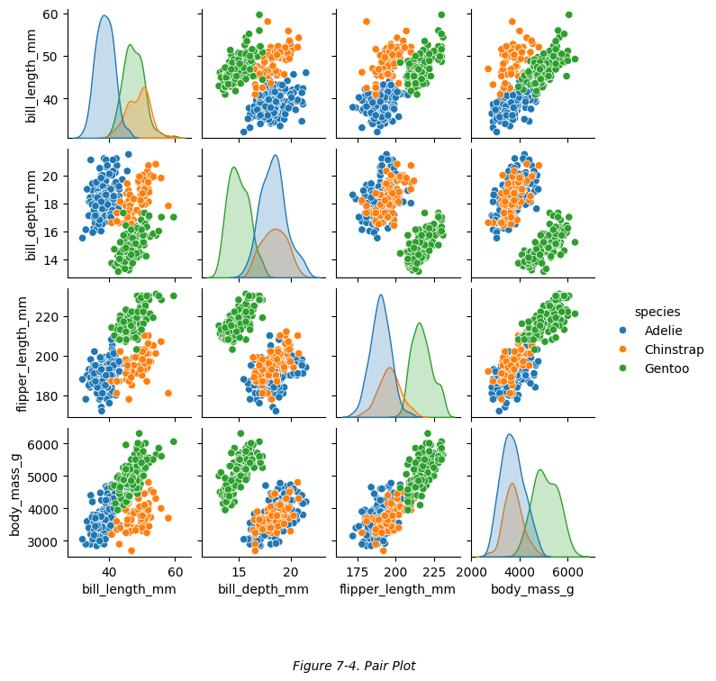

```python
# pair plots
sns.pairplot(data=df, hue='species',height=1.7) # height: 调整图片大小（只有高度和宽高比，没有宽度）

plt.figtext(0.5,-0.1,"Figure 7-4. Pair Plot",ha="center",fontsize=10,style='italic')
plt.show()
```

Figure 7-4 中，原 DataFrame 中的四个 ratio 变量（列）被自动识别，并作为数据画图。其中对角线的图是这四个变量各自的一元分布图，而除此之外的每个子图表都是基于一对变量（两个变量）绘制出的二元分布图。

同理，我们可以通过设置参数 `diag_kind` 和 `kind` 来修改对角线图表和其他二元图表的格式，如下图 (Figure 7-4)。

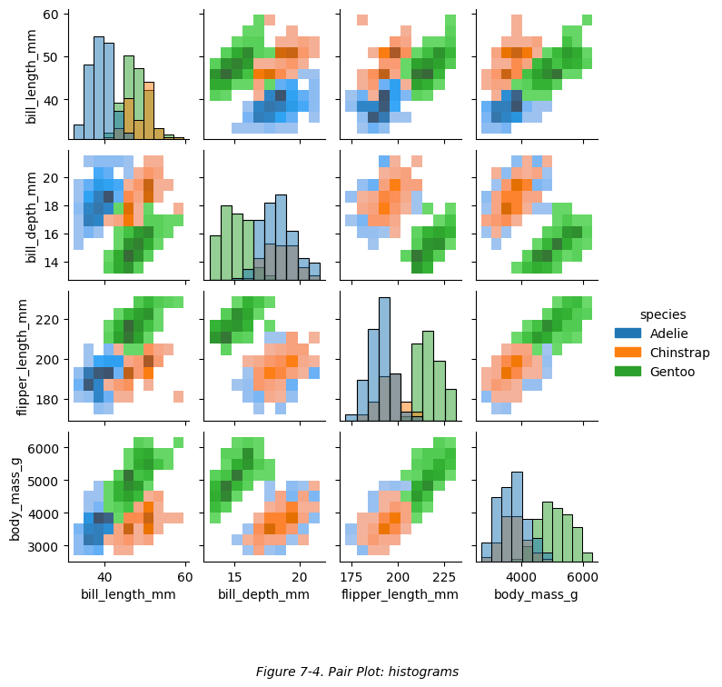

```python
# 加入两句 keyword arguments
sns.pairplot(
    data=df,
    hue='species',
    diag_kind='hist',  # kind of plot for the diagonal subplots 对角线图表的形式
    kind='hist',  # 每个二元分布图的形式（即，除了对角线之外的所有图表）
    height=1.7  # 调整图片大小
)

plt.figtext(0.5,-0.1,"Figure 7-4. Pair Plot: histograms",ha="center",fontsize=10,style='italic')
plt.show()
```

**⇧ 回到页面顶部**